# Socio-Economic Analysis of Champaign, Illinois, 2017

Arpita Banerjee.

4/21/2021

# Introduction

This notebook tries to look at the distribution of socio-economic data spanning race, age, income, poverty and housing characteristics across 3 spatial levels - the city, county and region through teh example of Champaign, IL. It then tries to understand scales for policy intervention after the recognition of different issues.

# 1. Race

This section explores the distribution of racial and ethnic groups - whites, blacks, latinos, Asians, etc. across three scales.

Racial Distribution in Champaign - City, County and Region, 2017

| NAME | pop_tot | pop_white | p_white | pop_black | p_black | pop_latino | p_latino | pop_asian | p_asian | pop_other | p_other |
| --- | --- | --- | --- | --- | --- | --- | --- | --- | --- | --- | --- |
| Champaign city, Illinois | 85710 | 56350 | 65.74495 | 15137 | 17.66072 | 5489 | 6.404153 | 10634 | 12.406954 | 3589 | 4.187376 |
| Champaign County, Illinois | 207946 | 151258 | 72.73908 | 27210 | 13.08513 | 11950 | 5.746684 | 21481 | 10.330086 | 7997 | 3.845710 |
| Region | 237849 | 179655 | 75.53322 | 27507 | 11.56490 | 12566 | 5.283184 | 21609 | 9.085176 | 9078 | 3.816707 |

[figure not shown]

This shows that the city of Champaign has a greater proportion of minority populations in comparison with the rest of the county and the region. The proportion of minorities is greater in Champaign County compared with populations of adjoining counties in the region.

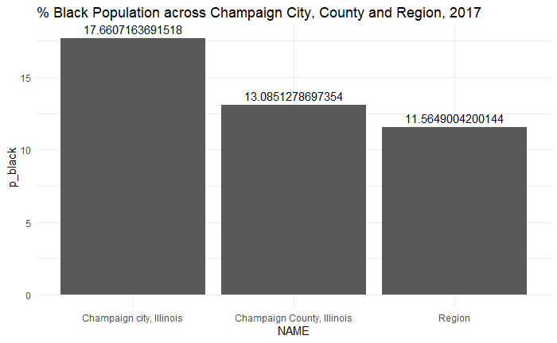

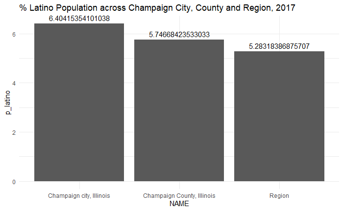

The proportion of Latinos remains fairly consistent across the city, county and region. There is hardly any difference at the county and regional levels, and a slightly greater (1%) proportion at the city level. Like the Latino population, other smaller minorities also maintain a consistent proportion of population across all levels.

# 2. Age

Age Distribution in Champaign - City, County and Region

| Age_Category | Champaign_City_Population | Champaign_City_Percentage | Champaign_County_Population | Champaign_County_Percentage | Region_Population | Region_Percentage |
| --- | --- | --- | --- | --- | --- | --- |
| 19 and Below | 21036 | 24.54323 | 53579 | 25.76582 | 61030 | 25.65914 |
| 20 to 44 | 41159 | 48.02123 | 87539 | 42.09699 | 95808 | 40.28102 |
| 45 to 64 | 14893 | 17.37604 | 39931 | 19.20258 | 47907 | 20.14177 |
| 65 and Above | 8622 | 10.05950 | 26897 | 12.93461 | 33104 | 13.91807 |

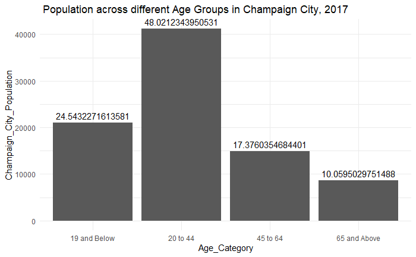

This shows that the city of Champaign has the greatest proportion of young persons and persons of working age (ranging from 0-44 years). The proportion of older persons is significantly less in the city, in comparison with the county and region.

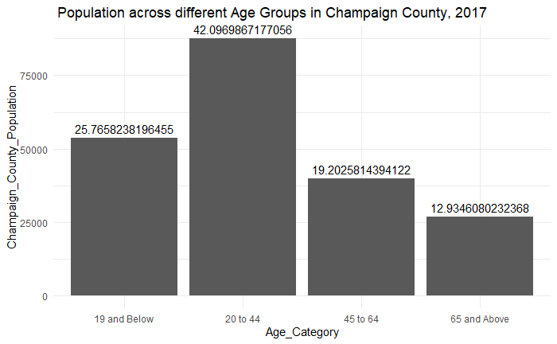

Since the proportion of youths and persons below 44 years of age continues to be high in the county, it acts as good container for the majority of the work force of the region. The proportion of older persons is greater here than at the city level.

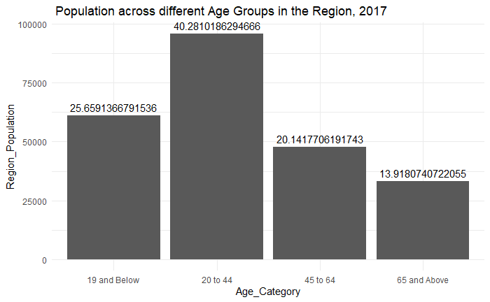

The proportion of older persons is highest at this scale, meaning that older persons mostly reside away from the city. Younger populations continue to be high, but their proportion is moderated by the increase in the number of persons above the age of 44.

# 3. Median Household Income

This section shows the distribution of income across different races and across three scales - the city, county and region. It shows the median income for all races, and then compares it with the distribution of income across whites, blacks, latinos, asians and other minority groups.

Income Distribution in Champaign - City, County and Region

| NAME | MHHI_tot | MHHI_white | MHHI_black | MHHI_latino | MHHI_Asian | MHHI_other |
| --- | --- | --- | --- | --- | --- | --- |
| Champaign city, Illinois | 44638 | 52051 | 29256 | 40569 | 22579 | 47634 |
| Champaign County, Illinois | 49586 | 56344 | 30339 | 38452 | 24215 | 48811 |
| Region | 50851 | 56344 | 30339 | 41726 | 24215 | 48811 |

# 4 Female Headed Households

This section explores the distribution of female headed households across the city, county and region scales. It also takes into account that female headed households can suffer important ramifications owing to race and therefore takes into account both the number and proportion of female headed houses as per their racial groups.

Distribution of Female Headed Households in Champaign - City, County and Region, 2017

| NAME | femaleHH_tot | femaleHH_white | Percent_White | femaleHH_black | Percent_Black | femaleHH_latino | Percent_Latino | femaleHH_Asian | Percent_Asian | femaleHH_AIAN | Percent_AIAN | femaleHH_other | Percent_other |
| --- | --- | --- | --- | --- | --- | --- | --- | --- | --- | --- | --- | --- | --- |
| Champaign city, Illinois | 2858 | 1382 | 48.35549 | 1194 | 41.77747 | 173 | 6.053184 | 121 | 4.233730 | 0 | 0 | 22 | 0.7697691 |
| Champaign County, Illinois | 7618 | 4463 | 58.58493 | 2447 | 32.12129 | 425 | 5.578892 | 328 | 4.305592 | 0 | 0 | 85 | 1.1157784 |
| Region | 8906 | 5692 | 63.91197 | 2465 | 27.67797 | 487 | 5.468224 | 334 | 3.750281 | 0 | 0 | 103 | 1.1565237 |

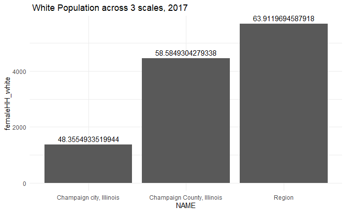

Both the number and percentage of white population and white female headed households are greater beyond the Champaign city. The distribution of female households confirm that although the population of minority groups is not evenly distributed across the three scales. This also means that Champaign City that houses a majority of the minority female headed households is the most vulnerable of all scales and concerted efforts should be directed at the urban scale.

# 5. Poverty

This section explores the intersection between age and poverty. It tries to build a relationship between the working-age of the population and the proportion of poor persons belonging to different age groups across the three scales.

Proportion of Different Age Groups for Poverty in Champaign - City, County and Region

| age_cat | ChampaignCity_poverty_total | ChampaignCitypercent_pov | ChampaignCounty_poverty_total | ChampaignCountypercent_pov | Region_poverty_total | Region_percent_pov |
| --- | --- | --- | --- | --- | --- | --- |
| 18 to 44 | 15323 | 73.078024 | 27983 | 68.105043 | 29010 | 65.901863 |
| 45 to 64 | 1780 | 8.489126 | 4092 | 9.959112 | 4560 | 10.358928 |
| 65 and Above | 600 | 2.861503 | 1780 | 4.332165 | 2099 | 4.768287 |
| Below 18 | 3265 | 15.571347 | 7233 | 17.603680 | 8351 | 18.970922 |

The highest proportion of poverty is found amongst persons of working age. The concentration of poverty in this age bracket (between 20-44) can also be due to the presence of a high number of University students in the area. This effect gets moderated across the rest of the scales.

Populations above the age of 65 are the least poor across all the different scales. Measures of poverty should be more directed at the city level, since the maximum number of poor persons reside at the urban level.

# 6. Housing Tenure (Owners and Renters)

In this section we have a look at the percentage of owned versus rented households across the three scales. It is the first step in understanding the relationship between income, poverty and housing conditions. It will be visible here that the majority of the population of Champaign City spend their lives in rental housing signifying that ownership of housing is difficult for majority of the people.

Distribution of Tenure in Champaign - City, County and Region

| NAME | tenure_tot | owned | rented | percent_owned | percent_rented |
| --- | --- | --- | --- | --- | --- |
| Champaign city, Illinois | 33834 | 15158 | 18676 | 44.80109 | 55.19891 |
| Champaign County, Illinois | 81418 | 44405 | 37013 | 54.53954 | 45.46046 |
| Region | 93778 | 53892 | 39886 | 57.46764 | 42.53236 |

The percentage of households living in rental housing is disproportionately high in case of Champaign City. As we move from the city towards the region, the % of households owing their housing units increase substantially. A majority of the population owns their housing as we move from the city to the region level. However, it is interesting to note here that the percentage of rental housing or owned housing does not cross the 60-40 mark - meaning that although differences exist, they are not stark and tenure is not very unevenly distributed across the population at all 3 levels.

# 7. Median Home Value

This section explores the Median Home Value in US Dollars. Attempts will be made to try and link this information with the Tenure analysis, among others. The data is presented across 3 scales - the City, County and Region.

Median Home Values in Champaign - City, County and Region, 2017

| NAME | HomeValue_tot |
| --- | --- |
| Champaign city, Illinois | 156700 |
| Champaign County, Illinois | 154800 |
| Region | 128100 |

# 8. Housing Cost Burden

Housing cost burden is shown here in two ways - cost burden for owned houses and rent burden for rental housing. The overall percentage of all burdened households is also calculated across all three scales. This section will link itself to the analysis of median home value and tenure as well.

Housing Cost Burden in Champaign - City, County and Region

| NAME | Total | Owner_Occupied_Units | CostBurdened | Percent_CostBurdened | Rented_Units | RentBurdened | Percent_RentBurdened | Percent_Burdened |
| --- | --- | --- | --- | --- | --- | --- | --- | --- |
| Champaign city, Illinois | 33834 | 15158 | 2916 | 19.23737 | 18676 | 9126 | 48.86485 | 35.59142 |
| Champaign County, Illinois | 81418 | 44405 | 8251 | 18.58124 | 37013 | 18308 | 49.46370 | 32.62055 |
| Region | 93778 | 53892 | 9546 | 17.71320 | 39886 | 19322 | 48.44306 | 30.78334 |

Approximately 20% of the population is cost burdened whereas 50% is rent burdened. This is because the median home values are substantially high and most of the people ~ 50% have to reside in rental housing (owing to their incomes). If 50% of all rented households are rent burdened, therefore a quarter of all households across all spatial levels suffer from rent burden. At an overall level of housing cost burden, approximately 30% of total households struggle to meet their housing costs. This has important ramifications for urban and regional planning.

# 9. Residential Vacancy Rate

The last section tries to understand how the housing crises emanates on ground through the lens of housing vacancy. A high percentage of vacant housing determines that the existing housing lot is inadequate when it comes to satisfying the needs of the population.

| NAME | Total_units | Occupied | Vacant | Percent_occupied | Percent_vacant |
| --- | --- | --- | --- | --- | --- |
| Champaign city, Illinois | 37743 | 33834 | 3909 | 89.64311 | 10.35689 |
| Champaign County, Illinois | 90783 | 81418 | 9365 | 89.68419 | 10.31581 |
| Region | 104508 | 93778 | 10730 | 89.73284 | 10.26716 |

The Champaign city, county and region does not exhibit a stark housing vacancy rate, but combined with the proportion of rental housing and rent burden, it reflects a need to reevaluate the present housing stock in order to understand which income groups it is currently cateing to.

# Conclusions

Analyzing socio-economic data - race, age, income and housing charateristics helps understand the scale of policy intervention. When it comes to interventions on income and poverty, the city level is the most useful. Female Headed Households are also concentrated at the city level and their vulnerable situation can be best tackled through policies directed at this scale. Housing problems of rent burden are uniformly distributed across all scales and can be best handled through interventions at the regional scale. Understanding the distribution of characteristics across different scales helps understand the primacy of Champaign City within the larger region.